# Homework 5

Jun Ryu

2023-06-15

```r
knitr::opts_chunk$set(echo = TRUE)
library(tidyverse)
library(dplyr)
```

## Question 1

### a)

```r
a <- 1
b <- c(1, 1)
C <- matrix(c(7.5, 2, 1, 1.25), nrow = 2, ncol = 2)

g <- function(w) {
  a + t(b) %*% w + t(w) %*% C %*% w
}

gradient <- function(w) {
  b + 2*C %*% w
}

hessian <- function(w) {
  2*C
}

w <- matrix(c(-10,1))
weight_history <- w
for (i in 1:100) {
  if (norm(gradient(w), type = "2") < 10^-5) {
    break
  }

  w <- w - solve(hessian(w)) %*% gradient(w)
  weight_history <- cbind(weight_history, w)
}

weight_history
```

```
##      [,1]        [,2]
## [1,]  -10 -0.01694915
## [2,]    1 -0.37288136
```

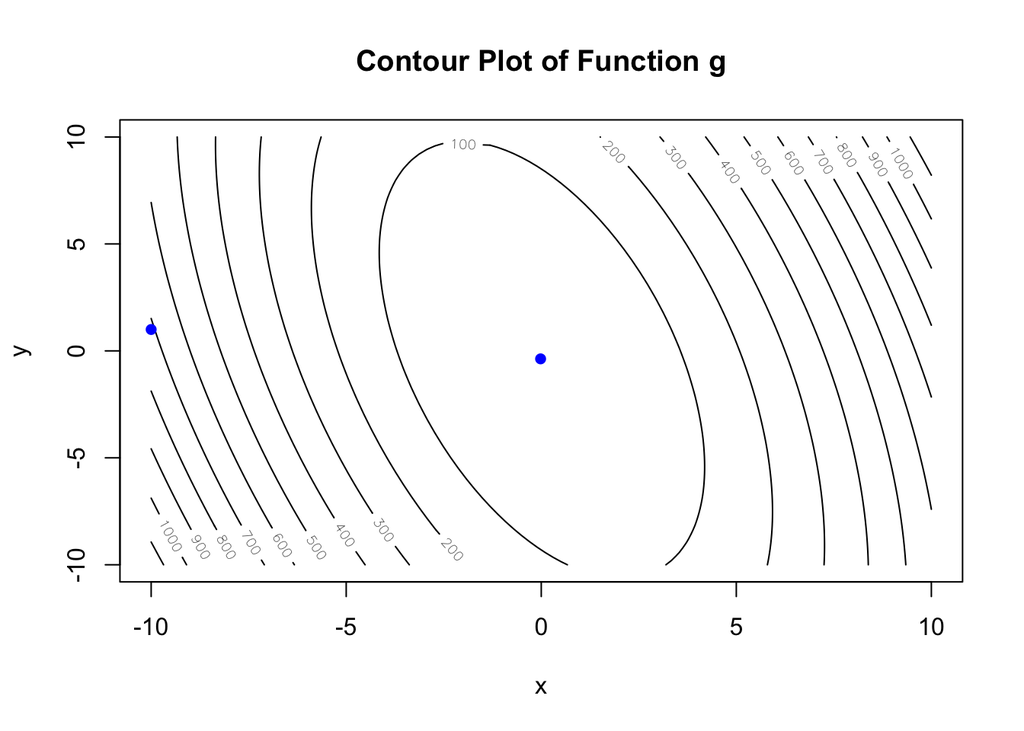

```r
x <- seq(-10, 10, length.out = 100)
y <- seq(-10, 10, length.out = 100)
z <- matrix(apply(expand.grid(x,y),1,FUN=g), nrow=100)

contour(x, y, z, xlab = "x", ylab = "y", main = "Contour Plot of Function g")
points(weight_history[1,], weight_history[2,], col = "blue", pch = 16)
```

### b)

```r
# subsampled Newton's

w <- matrix(c(-10,1))
weight_history <- w
for (i in 1:100) {
  if (norm(gradient(w), type = "2") < 10^-5) {
    break
  }

  w_1 <- w[1] - (solve(hessian(w[1])) %*% gradient(w))[1]
  w_2 <- w[2] - (solve(hessian(w[2])) %*% gradient(w))[2]
  w <- matrix(c(w_1,w_2))
  weight_history <- cbind(weight_history, w)
}

weight_history
```

```
##      [,1]        [,2]
## [1,]  -10 -0.01694915
## [2,]    1 -0.37288136
```

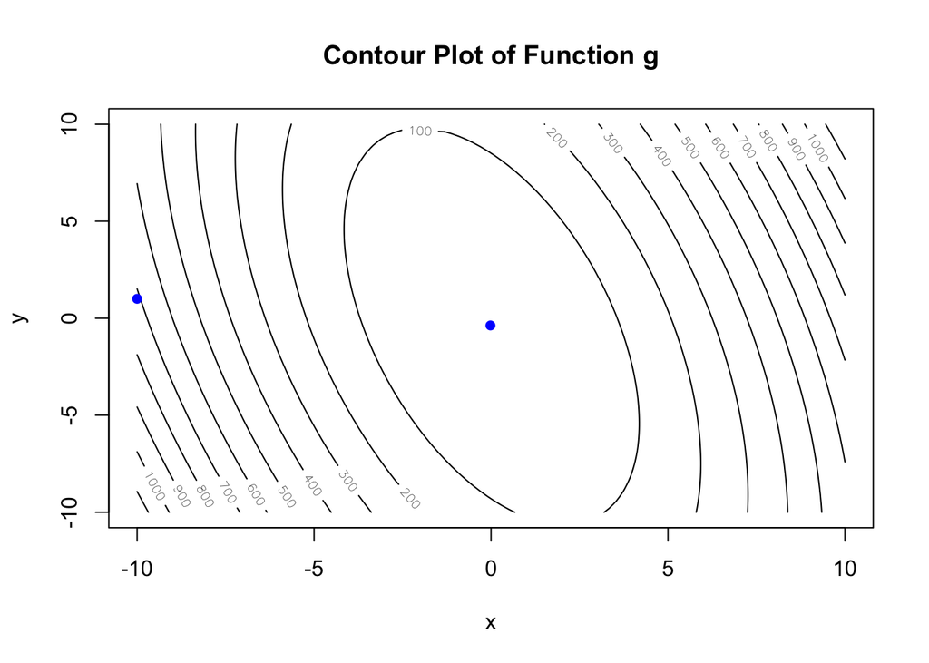

```r
x <- seq(-10, 10, length.out = 100)
y <- seq(-10, 10, length.out = 100)
z <- matrix(apply(expand.grid(x,y),1,FUN=g), nrow=100)

contour(x, y, z, xlab = "x", ylab = "y", main = "Contour Plot of Function g")
points(weight_history[1,], weight_history[2,], col = "blue", pch = 16)
```

From this, we do not really observe any differences from part a); in fact, the result is identical. This is because, since our Hessian matrix is a 2x2 matrix that does not depend on our input vector w, we don’t need to resort to the subsampling method used in part b).

### c)

We have that the Hessian of g is simply equal to 2*C. Finding the eigenvalues for the Hessian matrix:

```r
eigen(2*C)$values
```

```
## [1] 15.610211  1.889789
```

Thus, for any input w, the Hessian will always contain positive eigenvalues, meaning that g is a convex function. Therefore, since g is convex, the stationary point found is also a global minimum.

## Question 2

### a)

```r
a <- c(5,4)
b <- c(1,-2)
c <- c(-1,1)
d <- c(3,1)

# starting with initial groups G1 = (A,B) and G2 = (C,D)
g1_med <- (a+b)/2
g2_med <- (c+d)/2

# start with point A:
norm(matrix(a-g1_med), type="2")
```

```
## [1] 3.605551
```

```r
norm(matrix(a-g2_med), type="2")
```

```
## [1] 5
```

```r
# A stays in G1, we move to B without adjusting median values:
norm(matrix(b-g1_med), type="2")
```

```
## [1] 3.605551
```

```r
norm(matrix(b-g2_med), type="2")
```

```
## [1] 3
```

```r
# B is closer to G2, so move B to G2 and adjust median values:
g1_med <- a
g2_med <- (b+c+d)/3

# now, do the procedure for point C
norm(matrix(c-g1_med), type="2")
```

```
## [1] 6.708204
```

```r
norm(matrix(c-g2_med), type="2")
```

```
## [1] 2.236068
```

```r
# C stays in G2, move to D:
norm(matrix(d-g1_med), type="2")
```

```
## [1] 3.605551
```

```r
norm(matrix(d-g2_med), type="2")
```

```
## [1] 2.236068
```

```r
# D stays in G2, and since A is still closer to G1 after the adjusted median values, the algorithm ends here
```

Thus, the two final clusters are G1: A and G2: B,C,D.

### b)

```r
# starting with initial groups G1 = (A,C) and G2 = (B,D)
g1_med <- (a+c)/2
g2_med <- (b+d)/2

# start with point A:
norm(matrix(a-g1_med), type="2")
```

```
## [1] 3.354102
```

```r
norm(matrix(a-g2_med), type="2")
```

```
## [1] 5.408327
```

```r
# A stays in G1, we move to B without adjusting median values:
norm(matrix(b-g1_med), type="2")
```

```
## [1] 4.609772
```

```r
norm(matrix(b-g2_med), type="2")
```

```
## [1] 1.802776
```

```r
# B stays in G2, we move to C:
norm(matrix(c-g1_med), type="2")
```

```
## [1] 3.354102
```

```r
norm(matrix(c-g2_med), type="2")
```

```
## [1] 3.354102
```

```r
# C can stay in G1 (since same distance to G1 and G2), we move to D:
norm(matrix(d-g1_med), type="2")
```

```
## [1] 1.802776
```

```r
norm(matrix(d-g2_med), type="2")
```

```
## [1] 1.802776
```

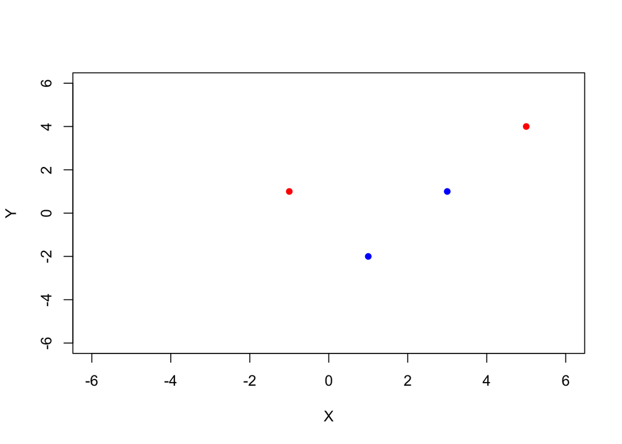

```r
# D stays in G2 (since same distance to G1 and G2), and algorithm ends here

# plot (red pts in G1, blue pts in G2):
plot(0, 0, type = "n", xlim = c(-6, 6), ylim = c(-6, 6), xlab = "X", ylab = "Y")
points(a[1], a[2], pch = 16, col = "red")
points(b[1], b[2], pch = 16, col = "blue")
points(c[1], c[2], pch = 16, col = "red")
points(d[1], d[2], pch = 16, col = "blue")
```

The result is a bit different from part a): the two final clusters are G1: A,C and G2: B,D. Looking at the plot above, the clusters seem to make sense. The red points can create a rather wide cluster and the blue points can create one too (but narrower) due to their proximity.

### c)

```r
# starting from point D with initial groups G1 = (A,B) and G2 = (C,D)
g1_med <- (a+b)/2
g2_med <- (c+d)/2

# point D:
norm(matrix(d-g1_med), type="2")
```

```
## [1] 0
```

```r
norm(matrix(d-g2_med), type="2")
```

```
## [1] 2
```

```r
# D is closer to G1, so move D to G1 and adjust median values:
g1_med <- (a+b+d)/3
g2_med <- c

# point C:
norm(matrix(c-g1_med), type="2")
```

```
## [1] 4
```

```r
norm(matrix(c-g2_med), type="2")
```

```
## [1] 0
```

```r
# C stays in G2, we move to B without adjusting median values:
norm(matrix(b-g1_med), type="2")
```

```
## [1] 3.605551
```

```r
norm(matrix(b-g2_med), type="2")
```

```
## [1] 3.605551
```

```r
# B can stay in G1 (since same distance to G1 and G2), we move to A:
norm(matrix(a-g1_med), type="2")
```

```
## [1] 3.605551
```

```r
norm(matrix(a-g2_med), type="2")
```

```
## [1] 6.708204
```

```r
# A stays in G1, and the algorithm ends here
```

Thus, the two final clusters are G1: A,B,D and G2: C. This is different from what was achieved in parts a) and b). These results need not be the same because varying these conditions (starting point, initial clusters) can often result in different outcomes.

## Question 3

### a)

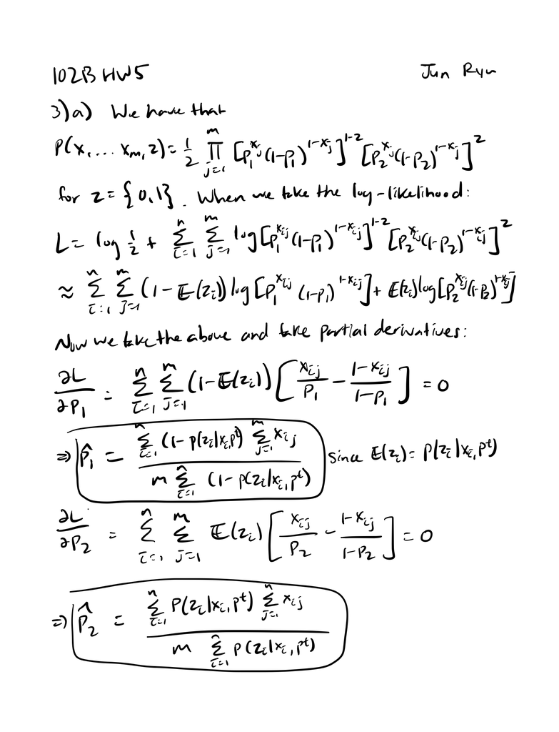

```r
knitr::include_graphics("hw5_q3_1.png")
```

### b)

```r
em_alg <- function(rolls, theta_A=runif(1), theta_B=runif(1), max_iter=10) {
  # Runs the EM algorithm for coin flipping
  # Args:
  # rolls: a vector with each element containing a series of coin flipping results
  # theta_A: the initial value for theta_A
  # theta_B: the initial value for theta_B
  # max_iter: the max number of iterations
  # Return:
  # thetas: the matrix containing all the theta_A and theta_B updates

  thetas <- matrix(c(theta_A, theta_B), ncol = 2)
  for (i in 1:max_iter) {
    e_result <- e_step(rolls, theta_A, theta_B)
    m_result <- m_step(e_result$heads_A, e_result$tails_A, e_result$heads_B, e_result$tails_B)
    theta_A <- m_result$theta_A
    theta_B <- m_result$theta_B
    thetas <- rbind(thetas, c(theta_A, theta_B))
  }
  thetas
}

e_step <- function(rolls, theta_A, theta_B) {
  # Runs the E-step
  # Args:
  # rolls: a vector with each element containing a series of coin flipping results
  # theta_A: theta_A value at each step of the algorithm
  # theta_B: theta_A value at each step of the algorithm
  # Return:
  # a list with cumulative expected counts for heads and tails using both coins
  heads_A <- 0
  tails_A <- 0
  heads_B <- 0
  tails_B <- 0
  for (trial in rolls) {
    head <- str_count(trial, "H")
    likelihood_A <- theta_A^head * (1 - theta_A)^(nchar(trial) - head)
    likelihood_B <- theta_B^head * (1 - theta_B)^(nchar(trial) - head)
    p_A <- likelihood_A / (likelihood_A + likelihood_B)
    p_B <- likelihood_B / (likelihood_A + likelihood_B)
    heads_A <- heads_A + p_A * str_count(trial, "H")
    tails_A <- tails_A + p_A * str_count(trial, "T")
    heads_B <- heads_B + p_B * str_count(trial, "H")
    tails_B <- tails_B + p_B * str_count(trial, "T")
  }
  return (list(heads_A = heads_A, tails_A = tails_A, heads_B = heads_B, tails_B = tails_B))
}

m_step <- function(heads_A, tails_A, heads_B, tails_B) {
  # Runs the M-step
  # Args:
  # heads_A, tails_A, heads_B, tails_B: cumulative expected counts derived in E-step
  # Return:
  # a list with updated theta_A and theta_B from previous iteration
  theta_A <- heads_A / (heads_A + tails_A)
  theta_B <- heads_B / (heads_B + tails_B)
  return (list(theta_A = theta_A, theta_B = theta_B))
}

rolls <-  c("HTTTHHTHTH", "HHHHTHHHHH", "HTHHHHHTHH", "HTHTTTHHTT", "THHHTHHHTH")
result <- em_alg(rolls, 0.6, 0.5, max_iter=6)
result
```

```
##           [,1]      [,2]
## [1,] 0.6000000 0.5000000
## [2,] 0.7130122 0.5813393
## [3,] 0.7452920 0.5692558
## [4,] 0.7680988 0.5495359
## [5,] 0.7831646 0.5346175
## [6,] 0.7910552 0.5262812
## [7,] 0.7945325 0.5223904
```

## Question 4

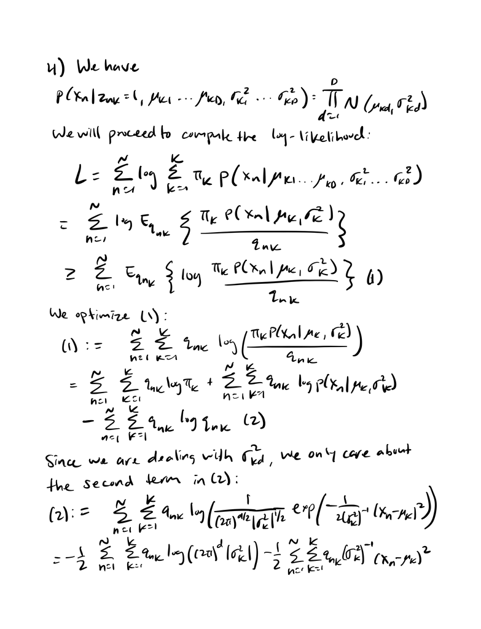

```r
knitr::include_graphics("hw5_q4_1.png")
```

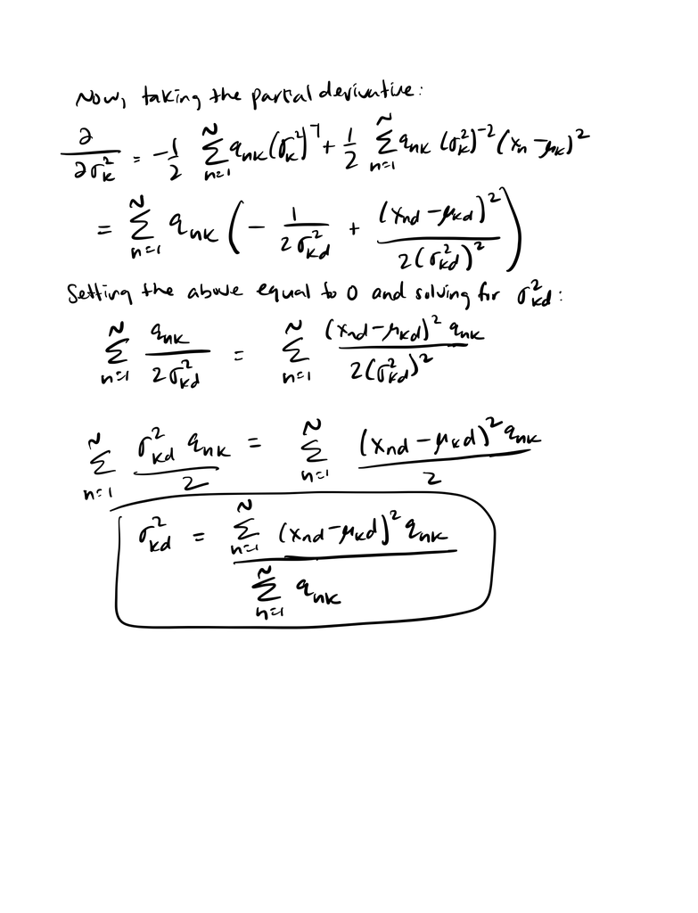

```r
knitr::include_graphics("hw5_q4_2.png")
```